# Simulation experiment (5)

## Design of the experiment

The design of the experiment is analogous to the experiment with normally distributed data, but some alterations were made to accommodate strictly postive variables (eg. ECEC, bulk density, …).

We simulate data according to the following method (notation: $X$ = non-reference method, $Y$ = reference method). We first simulate a latent (true) value for the non-reference method using a Gamma distribution with shape parameter $\alpha$ and rate parameter $\beta$. The Gamma distribution parameters are related to the mean and coefficient of variation ($CV = \sigma/\mu$) of $X$ and we specify those to create a scenario:

$$\begin{align}
\alpha &= CV_X^{-2} \\
\beta &= \frac{CV_X^{-2}}{\mu_X} \\
X_{\mathrm{true}} &\sim \mathcal{G}(\alpha, \beta)
\end{align}$$

We then use this value to simulate a value for the latent reference method $Y$, assuming a linear relation between both methods on the log-scale and some structural noise that is not due to measurement error. This structural noise needs to be multiplicative to avoid negative values; we sample $Y$ therefore from a Gamma distribution with a shape parameter reflecting the residual coefficient of variation (conditional on $X$; $CV_{Y|X}$):

$$\begin{align}
\mu_Y &= \exp\left(\gamma_0 + \gamma_1\log(X_{\mathrm{true}})\right) \\
Y_{\mathrm{true}} &\sim \mathcal{G}\left(CV_{Y|X}^{-2}, \frac{CV_{Y|X}^{-2}}{\mu_Y}\right)
\end{align}$$

We then add measurement noise to both methods (resulting from both field and lab measurement processes). Again, the noise is multiplicative ($X_{\mathrm{obs}} = X_{\mathrm{true}}\epsilon_u$, $Y_{\mathrm{obs}} = Y_{\mathrm{true}}\epsilon_v$) to avoid negative values and we take Gamma-distributed noises with expected values 1 (unbiased noise). Just like in the gaussian case, the measurement noise magnitudes are expressed as fractions of the $CV$ of the latent $X$:

$$\begin{aligned}
CV_{\epsilon_u} &= \tau_xCV_X \\
CV_{\epsilon_v} &= \tau_{xy}CV_{\epsilon_u}
\end{aligned}$$

We allow for correlated measurement noise between both methods using a Gaussian copula; we start by sampling a bivariate variable $Z$ with zero mean, unit variance and correlation coefficient $\rho$, this variable is then transformed to the unit-interval by means of the standard-normal CDF $\Phi_\mathcal{N}$ and then transformed to a Gamma-distributed measurement error by means of the Gamma quantile function $\Phi_\mathcal{G}^{-1}$:

$$\begin{align}
\begin{pmatrix} Z_1\\ Z_2 \end{pmatrix}
&\sim \mathcal{N}
\left(
\begin{pmatrix} 0\\ 0 \end{pmatrix},
\begin{pmatrix} 1 & \rho \\ \rho & 1 \end{pmatrix}
\right) \\
U &= \Phi_\mathcal{N}(Z_1) \\
V &= \Phi_\mathcal{N}(Z_2) \\
\epsilon_u &= \Phi_\mathcal{G}^{-1}(U; \alpha=\beta=CV_{\epsilon_u}^{-2}) \\
\epsilon_v &= \Phi_\mathcal{G}^{-1}(V; \alpha=\beta=CV_{\epsilon_v}^{-2})
\end{align}$$

In this experiment we focus on the effect of the sample size of the training dataset ($N$) and the amount of residual variation $CV_{Y|X}$. Other parameter values are kept fixed:

Table: Parameter values for the scenario’s of experiment 5.

| Parameter | Values |
| --- | --- |
| $N$ | 100, 200, 500 |
| $\mu_X$ | 1 |
| $CV_X$ | 0.5 |
| $\alpha$ | 0 |
| $\beta$ | 1 |
| $CV_{Y\|X}$ | 0.01, 0.05, 0.1, 0.2 |
| $\tau_x$ | 0.05 |
| $\tau_{xy}$ | 1 |
| $\rho$ | 0 |

## Models

We apply several models on the observed data to predict new observations. Contrary to the gaussian experiments, prediction occurs on the fly (during model fitting) because the closed-form expression for the latent values in the EIV models does not exist anymore. For the simulation experiment this is fine, but we need to find a true post-hoc solution for users later on so they don’t have to fit a model again. I found a solution with help from Claude-AI but it was extremely slow.

### Linear regression

We ignore the fact that the outcome variable is a strictly positive variable and use simple linear regression. We include this model as a naive method and look at the proportion of samples for which the predicted value is negative or the prediction interval contains negative values. Priors are similar to the gaussian experiments:

$$\begin{aligned}
\beta_0 &\sim \mathcal{N}(0, 1^2) \\
\beta_1 &\sim \mathcal{N}^+(1, 0.5^2) \\
\sigma_y &\sim \log\mathcal{N}(0, 0.5) \\
y_{\text{obs},i} &\sim \mathcal{N}(\beta_0 + \beta_1x_{\text{obs},i}, \sigma_y^2)
\end{aligned}$$

### Linear regression using log-transformed values

Same model as above but on log-transformed variables.

$$\begin{aligned}
\beta_0 &\sim \mathcal{N}(0, 1^2) \\
\beta_1 &\sim \mathcal{N}^+(1, 0.5^2) \\
\sigma_y &\sim \log\mathcal{N}(0, 0.5) \\
\mu_i &= \beta_0 + \beta_1\log(x_{\text{obs},i}) \\
\log(y_{\text{obs},i}) &\sim \mathcal{N}(\mu_i, \sigma_y^2)
\end{aligned}$$

### Gamma GLM

We don’t transform the outcome variable but assume it is Gamma-distributed with shape parameter $\alpha$ and rate $\alpha/\mu_i$, the log expected value follows a linear function of the log of the non-reference method:

$$\begin{aligned}
\beta_0 &\sim \mathcal{N}(0, 1^2) \\
\beta_1 &\sim \mathcal{N}^+(1, 0.5^2) \\
\alpha &\sim \log\mathcal{N}(0, 1) \\
\mu_i &= \exp(\beta_0 + \beta_1 \log(x_{obs,i})) \\
y_{\text{obs},i} &\sim \mathcal{G}(\alpha, \alpha/\mu_i)
\end{aligned}$$

### Gamma EIV-model with known CV of the measurement error

We take the measurement error in the non-reference method into account. In this model we assume we have knowledge on the exact value of the CV of the measurement error ($CV_{\epsilon_X}$). The model and the priors are as follows:

$$
$$\begin{aligned}
\mathrm{priors}\\
\beta_0 &\sim \mathcal{N}(0, 1^2) \\
\beta_1 &\sim \mathcal{N}^+(1, 0.5^2) \\
\alpha &\sim \log\mathcal{N}(0, 1) \\
\mu_X &\sim \log\mathcal{N}(0, 1) \\
CV_X &\sim \log\mathcal{N}(0, 1) \\
\mathrm{latent} \\
x_{true,i} &\sim \mathcal{G}(CV_X^{-2}, CV_X^{-2}/\mu_X)\\
x_{\text{obs},i} &\sim \mathcal{G}(CV_{\epsilon_X}^{-2}, CV_{\epsilon_X}^{-2}/x_{true,i}) \\
\mathrm{regression}\\
\mu_i &= \exp(\beta_0 + \beta_1 \log(x_{true,i})) \\
y_{\text{obs},i} &\sim \mathcal{G}(\alpha, \alpha/\mu_i)
\end{aligned}$$

$$

### Gamma EIV-model with unknown CV of the measurement error

The only difference with the above model is that we don’t have exact knowledge on the CV of the measurement error but we specify a prior distribution for it (we actually specify a prior for the gamma shape parameter directly):

$$CV_{\epsilon_X}^{-2} \sim \log\mathcal{N}(0, 1)$$

## Results

### Predictions

Figure

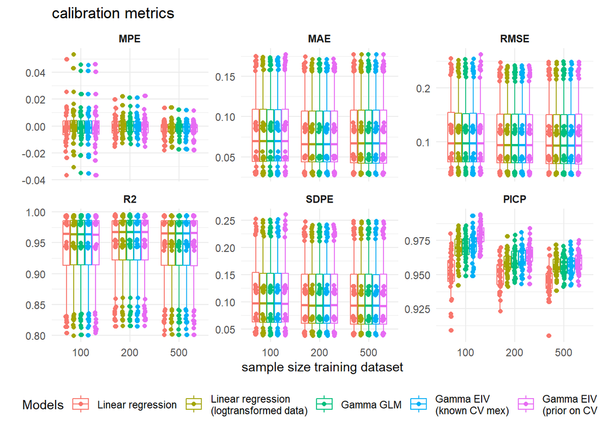

Figure 1: Results of the simulation experiment: effect of sample size on calibration metrics (aggregated across different levels of residual CV). Each facet has a different y-axis because the calibration metrics are on different scales.

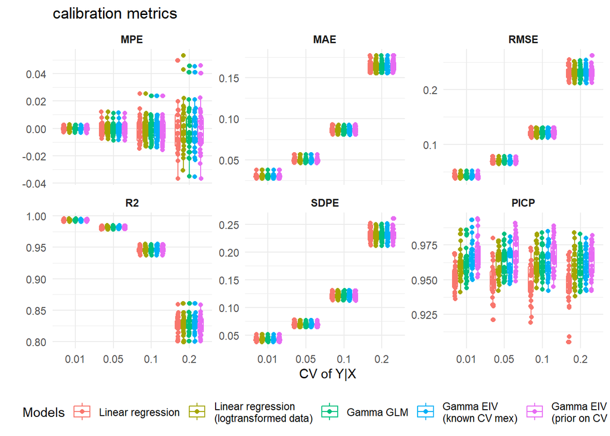

Figure 2: Results of the simulation experiment: effect of residual CV on calibration metrics (aggregated across different sample sizes). Each facet has a different y-axis because the calibration metrics are on different scales.

The linear regression model suffers from the inability to constrain predictions and prediction intervals to the positive real line. The other models don’t have this deficiency.

```
# A tibble: 4 × 3
  model                   replicates with at least 1 po…¹ replicates with at l…²
  <chr>                                             <int>                  <int>
1 linreglogtrafo                                        0                      0
2 gammareg                                              0                      0
3 gammaregeivknowncvmex                                 0                      0
4 gammaregeivunknowncvmex                               0                      0
# ℹ abbreviated names: ¹`replicates with at least 1 positive prediction`,
#   ²`replicates with at least 1 positive prediction interval`
```

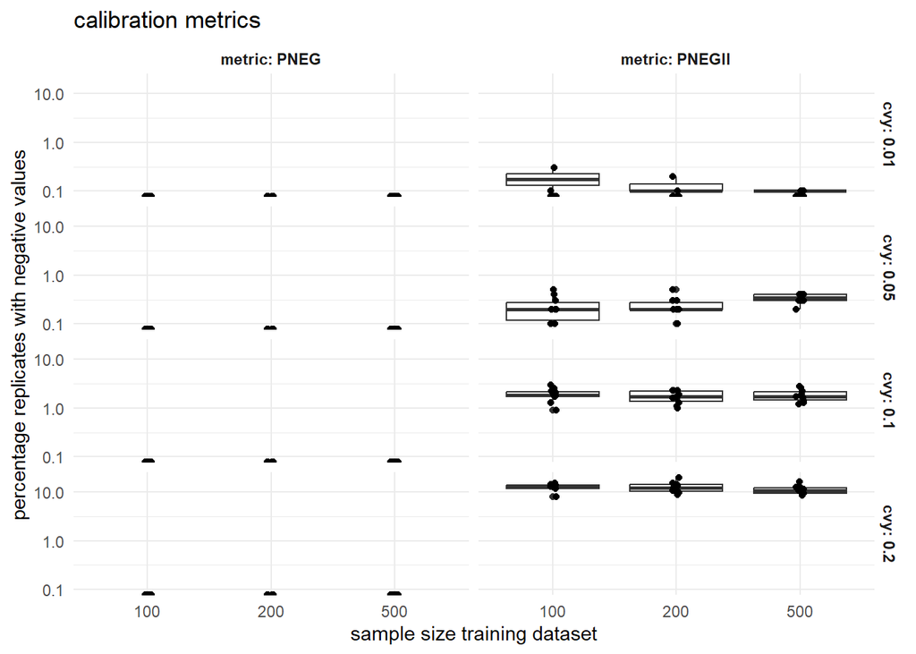

Figure 3: Linear regression: proportion of replicates with negative predictions or negative prediction intervals

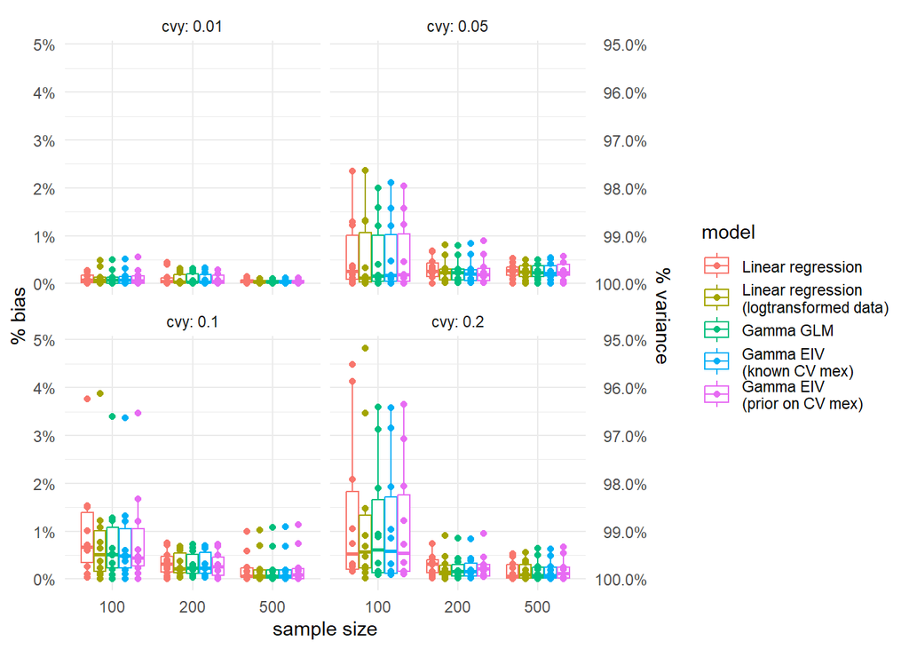

Figure 4: Results of the simulation experiment: %bias and %variance

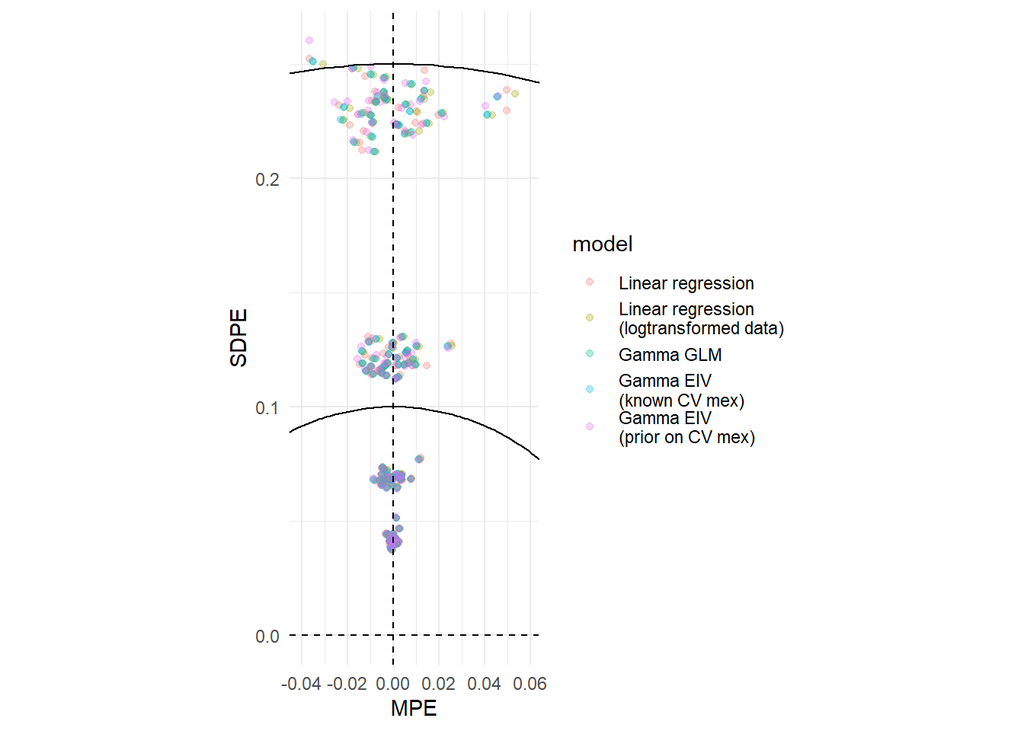

Figure 5: Results of the simulation experiment: MPE vs. SDPE. All points on the circles have the same RMSE. Aggregated across scenario’s

### Model diagnostics: MCMC $\hat{R}$

The following figures display the $\hat{R}$ statistic of the MCMC for each of the model parameters. The red dashed lines are at 1.00 and 1.01. The boxplots are aggregated across scenario’s. The Gamma EIV-model with unknown $CV$ of the measurement error suffers from poor mixing.

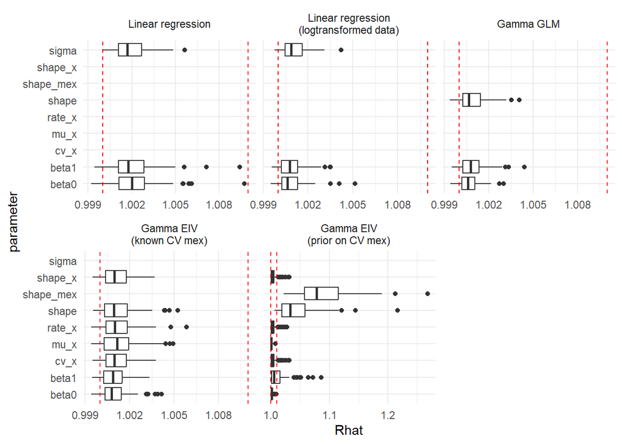